# Models template

Nick Borg

September 23, 2016

This is a generic template for predicting behavioral repsonses from fMRI data. We assume that you import behavioral and brain data from the same .csv file, in the format

```
TR, Trial, Behavioral_1, ...., ROI_TR_1, ROI_TR_2, ... ROI2_TR_1, ...
```

# Library imports

```r
library(dplyr)
library(lme4)
library(e1071)
library(lmtest)
library(lubridate)
library(knitr)
library(BaylorEdPsych)
```

# Load your data.

```r
 data_path <- '/Users/kelly/cueexp/data/relapse_data/relapse_data_180403.csv'
```

# Clean your data

I recommend this extra preprocessing step if you end up using trial based data: You need to look at which columns contain brain data, here they are columns 19:113. the colnames function is useful for that. (Remember that R is 1 indexed.)

```r
# #Remove Outliers with > 4 sd activations--non physiological (find reference? - cite Nik Sawe paper)
# max_act  =apply(as.matrix(df[19:113]), 1, function(x) { max(abs(x),na.rm=TRUE) } ) # this finds the largest ROI activation within a row of your data
# hist(max_act)
# df <- df[(max_act<4) & max_act > 0,]
# max_act  =apply(as.matrix(df[19:113]), 1, function(x) { max(abs(x),na.rm=TRUE) } )
# hist(max_act)
```

# Evaluating a classifier.

In order to test a model on our data set, it would be nice if we could pass a single formula and get accuracy information from a classifier trained using that formula.

First of all, we assume that we have a single factor variable we want to predict that takes two values, so that as.numeric on your y yields (1, 2)

As an example, let’s say that I want to know what predicts stock movement in Mirre’s stock task. We’ll want to write a function call that looks like: (kable is a function that prints nice tables from a dataframe)

```r
formula <- as.formula('Result ~ Choice + (nacc8mmb_TR_4 + mpfcb_TR_4 + demartino_dmpfc8mmb_TR_4 + desai_insb_TR_4)* Previous_Trial + volatility + slope + (1|Subject)')
ans <- evalClassifier(df, formula, type='glm', split.method = 'average')
kable(ans)
```

Really, evalClassifier is just a high level function that does a tiny bit of data cleaning and calls a more basic function, .evalClassifier, which does the meat of the work. It lets us run more than one subject at a time, but otherwise it’s sending the work off to .evalClassifier and then putting the results in a dataframe which prints things neatly.

```r
evalClassifier <- function(df, formula, type='glm', split.method='8020', sep.subjects=FALSE, print.model=FALSE){
  # first get rid of any rows in which one of our variables is NA)
  formula.vars <- unlist(strsplit(gsub("[^[:alnum:]|'_' ]", "", as.character(formula)), c(' ')))
  for(v in formula.vars){
    if(v %in% colnames(df)) {
      df <- df[!is.na(df[v]), ]
    }
  }
  # make our results data frame.
  d.res <- data.frame()
  if(sep.subjects){
    #eval_model on each subjects
    for(subj in unique(df$Subject)){
      accuracies <- .evalClassifier(filter(df, Subject==subj), formula, type, split.method)
      d.res<- rbind(d.res, data.frame(Subject=subj, accuracies))
    }
    print(d.res)
    d.res <- d.res[order(-d.res$test.accuracy),] # order the subjects by their classifier accuracy
    # add the average of all the subjects
    d.res<- rbind(d.res, data.frame(Subject='Average', t(colMeans(d.res[,-1]))))
  } else {
    if(split.method=='loso'){
      #eval_model on each subjects
      if(type=='glm'){
        # first evaluate the entire model so as to print model summary information
        .evalClassifier(df, formula, type, split.method = 'none', print.model = print.model)
        }
      for(subj in unique(df$Subject)){
        accuracies <- .evalClassifier(df, formula, type, split.method, test.sub=subj, print.model = print.model)
        d.res<- rbind(d.res, data.frame(Subject=subj, accuracies))
      }
      print(d.res)
      d.res <- d.res[order(-d.res$test.accuracy),] # order the subjects by their classifier accuracy
      # add the average of all the subjects
      d.res<- rbind(d.res, data.frame(Subject='Average', t(colMeans(d.res[,-1]))))
    } else{
      accuracies <- .evalClassifier(df, formula, type, split.method, print.model=TRUE)
      d.res <- rbind(d.res, data.frame(data='All', accuracies))
    }
  }
  d.res
}
```

.evalClassifier is defined like so:

```r
.evalClassifier <- function(df, formula, type='glm', split.method='loso', test.sub = '',  print.model=FALSE){
  y <- all.vars(formula)[1] # get the y variable name to do train test splits

  if(split.method=='none' && type=='glm'){
    m <- fitModel(df, df, formula, type, print.model=TRUE)
  } else {
  train.test <<- trainTestSplit(df, split.method, y=y,test.sub=test.sub)
  m <- fitModel(df, train.test$train, formula, type, print.model)
  train.accuracy <- modelAccuracy(m, y, train.test$train, type)

  if(split.method=='loso'){
    test.accuracy  <- modelAccuracy(m, y, train.test$test, type, one_prediction=T)
    return( list('train.accuracy'=train.accuracy, 'test.accuracy'=test.accuracy[1], 'prediction'=test.accuracy[2], 'ground.truth' = test.accuracy[3]))
  } else{
    test.accuracy  <- modelAccuracy(m, y, train.test$test, type)
  }
   list('train.accuracy'=train.accuracy, 'test.accuracy'=test.accuracy[1])
  }
}
```

# Train test splits…

```r
trainTestSplit <- function(df, split.method='8020', y='result', test.sub="", downsample=T){
  set.seed(0)
  # Assume that the two responses are levels 1, 2 of a factor
  print(y)
  ind1 <- which(as.numeric(df[,y])==2)
  ind0 <- which(as.numeric(df[,y])==1)

  # downsample results. to upsample, use max and replace = TRUE
  # uncomment section below for one_subj
  if(downsample){
    try_again <- T
    while(try_again){
      sampsize <- min(length(ind1), length(ind0))
      sampind1 <- sample(ind1, sampsize, replace = FALSE)
      sampind0 <- sample(ind0, sampsize, replace = FALSE)
      sampind <- sample(c(sampind1,sampind0)) # the outside call to sample should randomize

      if (split.method=='loso' & !(test.sub %in% df[sampind,]$Subject)){
        try_again <- T
      }else{
        try_again <- F
      }
    }

  } else{
    sampind <- sample(1:nrow(df))
  }

  balanced.df <- df[sampind,]

  #Change response levels to 0,1 from 1, 2
  balanced.df[,y] <- factor(as.numeric(balanced.df[,y])-1, levels=c(0,1))

  #return last day
  if(split.method=='8020'){
    nrows <- nrow(balanced.df)
    train.ind <- sample(1:nrows, size=floor(.8 * nrows))
    test.ind <- c(1:nrows)[!c(1:nrows) %in% train.ind]
    d.train = balanced.df[train.ind,]
    d.test  =balanced.df[test.ind,]
    l <- list("train" = d.train, "test" = d.test)
  } else if(split.method=='loso'){
    train.ind <- balanced.df$Subject!= test.sub
    test.ind <- balanced.df$Subject==test.sub
    d.train <<- balanced.df[train.ind,]
    d.test  <<- balanced.df[test.ind,]
    l <- list("train" = d.train, "test" = d.test)
  } else {
    print('trainTestSplit called with split.method != 8020 or loso')
  }
  l
}
```

Lastly the fit model and predict accuracy functions are below:

```r
modelAccuracy <- function(m, y, d.test, type='glm', one_prediction=FALSE){
  cur.test <<- d.test
  if(type=='glm'){
    pred <<- predict(m, newdata = d.test, type = 'response', allow.new.levels = TRUE)
    pred.bin <<- factor(ifelse(pred >= 0.5,1,0), levels = c(0,1))
    stopifnot(nrow(cur.test)==length(pred.bin))

  }

  if(type=='svm'){
    pred  <<- predict(m, d.test, na.action = na.pass )
    pred.bin <<- factor(as.numeric(pred), levels=c(1,2), labels=c(0,1))
    stopifnot(nrow(cur.test)==length(pred.bin))

  }

  if(type=='naivebayes'){
    pred <<- predict(m, d.test, type='raw')[,2]
    pred.bin <<- factor(ifelse(pred >= 0.5,1,0), levels = c(0,1))
    stopifnot(nrow(cur.test)==length(pred.bin))

  }

  if(one_prediction){
    prediction <- as.integer(pred.bin[1]) - 1
  }
  class.tab = table(real=d.test[,y], model=pred.bin)
  #print(class.tab)
  acc <- (class.tab[1,1])/sum(class.tab)
  try(acc <- acc +  class.tab[2,2]/sum(class.tab))

  if(one_prediction){
    return(c(acc, prediction, as.integer(d.test[,y][1])-1))
  }
  acc
}

fitModel <- function(df, d.train, formula, type='glm', print.model=TRUE){
  # glimpse(d.train)
  needs.multilevel <- '|' %in% unlist(strsplit(gsub("[^[:alnum:]|'_' ]", "", as.character(formula)), c(' ')))
  if(type=='glm'){
    if(needs.multilevel){
      null_formula <- as.formula(paste(as.character(formula)[2], '~', '(1 | Subject)'))
      model <- glmer(formula, data = df, family = binomial(link = logit), control=glmerControl(optimizer="bobyqa"))
      m2 <- glmer(null_formula, data = df, family = binomial(link = logit), control=glmerControl(optimizer="bobyqa"))

      if(print.model){
        print(summary(model), correlation=T)
        if(needs.multilevel){
          print(rsquared.glmm(model))
        }
        print(lrtest(m2, model))
        print(anova(model))
        #print(confint(model))
      }
      model <- glmer(formula, data = d.train, family = binomial(link = logit), control=glmerControl(optimizer="bobyqa"))

    } else{
      null_formula <- as.formula(paste(as.character(formula)[2], '~', '1'))
      model <- glm(formula, data=df, family="binomial")
      m2 <- glm(null_formula, data=df, family="binomial")

      if(print.model){
        print(summary(model))
        print(PseudoR2(model))
        print(lrtest(m2, model))
        print(anova(model))
      }
      #print(summary(d.train))
      model <- glm(formula, data=d.train, family="binomial")
    }


  }
  if(type=='svm'){
     model <- svm(formula, data=d.train)
  }
  if(type=='naivebayes'){
    if(needs.multilevel){
      print('naiveBayes cannot handle interaction terms')
    } else{
      model <-  naiveBayes(formula, data=d.train)
    }
  }
  model
}
```

# Stuff for Kelly specifically

```r
setwd('/Users/kelly/cueexp/data/relapse_data/')
df = read.csv('relapse_data_180403.csv')
df<-df[is.na(df$relapse)==FALSE,]
#glimpse(df)
df$relIn6Mos = as.factor(df$relIn6Mos)
df$Subject <- df$subjid
```

```r
set.seed(0)
#formula <- as.formula("relIn6Mos ~ years_of_use + poly_drug_dep + clinical_diag")  # clinical model
#formula <- as.formula("relIn6Mos ~ pref_drug + craving + bam_upset")  # behavior model
#formula <- as.formula("relIn6Mos ~ nacc_drugs_beta + vta_drugs_beta +  mpfc_drugs_beta") # nacc+vta+mpfc
#formula <- as.formula("relIn6Mos ~ years_of_use + bam_upset + nacc_drugs_beta") # combined model
formula <- as.formula("relIn6Mos ~ nacc_drugs_beta")  # just nacc activity
#formula <- as.formula("relIn6Mos ~ nacc_food_beta")  # just nacc activity for neutral stim
#formula <- as.formula("relIn6Mos ~ nacc_drugs_beta + clinical_diag")
#formula <- as.formula("relIn6Mos ~ mpfc_drugs_beta + nacc_drugs_beta + vta_drugs_beta")

res <- evalClassifier(df, formula, type='glm', split.method='loso')
```

```
##
## Call:
## glm(formula = formula, family = "binomial", data = df)
##
## Deviance Residuals:
##     Min       1Q   Median       3Q      Max
## -1.7339  -0.7582  -0.3870   0.5507   1.7321
##
## Coefficients:
##                 Estimate Std. Error z value Pr(>|z|)
## (Intercept)       -0.511      0.420  -1.217  0.22371
## nacc_drugs_beta   21.631      7.562   2.860  0.00423 **
## ---
## Signif. codes:  0 '***' 0.001 '**' 0.01 '*' 0.05 '.' 0.1 ' ' 1
##
## (Dispersion parameter for binomial family taken to be 1)
##
##     Null deviance: 48.902  on 35  degrees of freedom
## Residual deviance: 34.847  on 34  degrees of freedom
## AIC: 38.847
##
## Number of Fisher Scoring iterations: 5
##
##         McFadden     Adj.McFadden        Cox.Snell       Nagelkerke
##        0.2874113        0.1647167        0.3232244        0.4350702
## McKelvey.Zavoina           Effron            Count        Adj.Count
##        0.4489199        0.3184270        0.7222222        0.3333333
##              AIC    Corrected.AIC
##       38.8469540       39.2105904
## Likelihood ratio test
##
## Model 1: relIn6Mos ~ 1
## Model 2: relIn6Mos ~ nacc_drugs_beta
##   #Df  LogLik Df  Chisq Pr(>Chisq)
## 1   1 -24.451
## 2   2 -17.424  1 14.055  0.0001775 ***
## ---
## Signif. codes:  0 '***' 0.001 '**' 0.01 '*' 0.05 '.' 0.1 ' ' 1
## Analysis of Deviance Table
##
```

[output cut: 68 more lines]

```
## 22 al170316      0.6896552             0          0            1
## 23 jd170330      0.6896552             0          0            1
## 24 jw170330      0.6206897             1          1            1
## 25 tg170423      0.6896552             0          0            1
## 26 jc170501      0.6206897             1          1            1
## 27 rl170603      0.6551724             1          0            0
## 28 rf170610      0.7586207             0          1            0
## 29 mr170621      0.6551724             1          0            0
## 30 ds170728      0.6551724             1          0            0
## 31 as170730      0.6551724             1          1            1
## 32 rc170730      0.6551724             1          1            1
## 33 rt170816      0.6896552             0          0            1
## 34 vb170914      0.6896552             0          1            0
## 35 ds170915      0.6551724             1          0            0
## 36 ts170927      0.6896552             0          1            0
```

```r
kable(res)
```

|  | Subject | train.accuracy | test.accuracy | prediction | ground.truth |
| --- | --- | --- | --- | --- | --- |
| 1 | ag151024 | 0.6551724 | 1.0000000 | 0.0000000 | 0.0000000 |
| 3 | wr151127 | 0.6551724 | 1.0000000 | 1.0000000 | 1.0000000 |
| 4 | ja151218 | 0.6551724 | 1.0000000 | 1.0000000 | 1.0000000 |
| 5 | wh160130 | 0.6551724 | 1.0000000 | 0.0000000 | 0.0000000 |
| 6 | nb160221 | 0.6551724 | 1.0000000 | 1.0000000 | 1.0000000 |
| 8 | ja160416 | 0.6551724 | 1.0000000 | 0.0000000 | 0.0000000 |
| 10 | tj160529 | 0.6551724 | 1.0000000 | 1.0000000 | 1.0000000 |
| 11 | at160601 | 0.6896552 | 1.0000000 | 0.0000000 | 0.0000000 |
| 12 | zm160627 | 0.7241379 | 1.0000000 | 0.0000000 | 0.0000000 |
| 13 | jf160703 | 0.6551724 | 1.0000000 | 0.0000000 | 0.0000000 |
| 14 | cg160715 | 0.7241379 | 1.0000000 | 0.0000000 | 0.0000000 |
| 15 | rs160730 | 0.6551724 | 1.0000000 | 0.0000000 | 0.0000000 |
| 16 | nc160905 | 0.6551724 | 1.0000000 | 0.0000000 | 0.0000000 |
| 17 | lm160914 | 0.7241379 | 1.0000000 | 0.0000000 | 0.0000000 |
| 18 | jb161004 | 0.6551724 | 1.0000000 | 0.0000000 | 0.0000000 |
| 21 | mr161024 | 0.6551724 | 1.0000000 | 0.0000000 | 0.0000000 |
| 24 | jw170330 | 0.6206897 | 1.0000000 | 1.0000000 | 1.0000000 |
| 26 | jc170501 | 0.6206897 | 1.0000000 | 1.0000000 | 1.0000000 |
| 27 | rl170603 | 0.6551724 | 1.0000000 | 0.0000000 | 0.0000000 |
| 29 | mr170621 | 0.6551724 | 1.0000000 | 0.0000000 | 0.0000000 |
| 30 | ds170728 | 0.6551724 | 1.0000000 | 0.0000000 | 0.0000000 |
| 31 | as170730 | 0.6551724 | 1.0000000 | 1.0000000 | 1.0000000 |
| 32 | rc170730 | 0.6551724 | 1.0000000 | 1.0000000 | 1.0000000 |
| 35 | ds170915 | 0.6551724 | 1.0000000 | 0.0000000 | 0.0000000 |
| 2 | si151120 | 0.6896552 | 0.0000000 | 0.0000000 | 1.0000000 |
| 7 | rv160413 | 0.6896552 | 0.0000000 | 0.0000000 | 1.0000000 |
| 9 | cm160510 | 0.6896552 | 0.0000000 | 1.0000000 | 0.0000000 |
| 19 | rc161007 | 0.6896552 | 0.0000000 | 0.0000000 | 1.0000000 |
| 20 | se161021 | 0.6896552 | 0.0000000 | 1.0000000 | 0.0000000 |
| 22 | al170316 | 0.6896552 | 0.0000000 | 0.0000000 | 1.0000000 |
| 23 | jd170330 | 0.6896552 | 0.0000000 | 0.0000000 | 1.0000000 |
| 25 | tg170423 | 0.6896552 | 0.0000000 | 0.0000000 | 1.0000000 |
| 28 | rf170610 | 0.7586207 | 0.0000000 | 1.0000000 | 0.0000000 |
| 33 | rt170816 | 0.6896552 | 0.0000000 | 0.0000000 | 1.0000000 |
| 34 | vb170914 | 0.6896552 | 0.0000000 | 1.0000000 | 0.0000000 |
| 36 | ts170927 | 0.6896552 | 0.0000000 | 1.0000000 | 0.0000000 |
| 110 | Average | 0.6733716 | 0.6666667 | 0.3611111 | 0.4166667 |

```r
print(res[nrow(res),])
```

```
##     Subject train.accuracy test.accuracy prediction ground.truth
## 110 Average      0.6733716     0.6666667  0.3611111    0.4166667
```

```r
res.glm <- res[nrow(res),]

class.tab = table(model=res$prediction[1:nrow(res)-1],ground.truth= res$ground.truth[1:nrow(res)-1])
```

```r
set.seed(0)
#formula <- as.formula("relIn6Mos ~ nacc_drugs_beta")  # just nacc activity
formula <- as.formula("relIn6Mos ~ nacc_drugs_beta")  # just nacc activity
res <- evalClassifier(df, formula, type='svm', split.method='loso')
```

[output not shown]

[output cut: 58 more lines]

```r
kable(res)
```

|  | Subject | train.accuracy | test.accuracy | prediction | ground.truth |
| --- | --- | --- | --- | --- | --- |
| 1 | ag151024 | 0.6551724 | 1.0000000 | 0.0000000 | 0.0000000 |
| 3 | wr151127 | 0.6896552 | 1.0000000 | 1.0000000 | 1.0000000 |
| 4 | ja151218 | 0.6896552 | 1.0000000 | 1.0000000 | 1.0000000 |
| 5 | wh160130 | 0.6896552 | 1.0000000 | 0.0000000 | 0.0000000 |
| 6 | nb160221 | 0.6896552 | 1.0000000 | 1.0000000 | 1.0000000 |
| 8 | ja160416 | 0.6896552 | 1.0000000 | 0.0000000 | 0.0000000 |
| 10 | tj160529 | 0.6896552 | 1.0000000 | 1.0000000 | 1.0000000 |
| 11 | at160601 | 0.6551724 | 1.0000000 | 0.0000000 | 0.0000000 |
| 12 | zm160627 | 0.7241379 | 1.0000000 | 0.0000000 | 0.0000000 |
| 13 | jf160703 | 0.6551724 | 1.0000000 | 0.0000000 | 0.0000000 |
| 14 | cg160715 | 0.7241379 | 1.0000000 | 0.0000000 | 0.0000000 |
| 15 | rs160730 | 0.6551724 | 1.0000000 | 0.0000000 | 0.0000000 |
| 16 | nc160905 | 0.6896552 | 1.0000000 | 0.0000000 | 0.0000000 |
| 17 | lm160914 | 0.7241379 | 1.0000000 | 0.0000000 | 0.0000000 |
| 18 | jb161004 | 0.7586207 | 1.0000000 | 0.0000000 | 0.0000000 |
| 21 | mr161024 | 0.6551724 | 1.0000000 | 0.0000000 | 0.0000000 |
| 27 | rl170603 | 0.6551724 | 1.0000000 | 0.0000000 | 0.0000000 |
| 29 | mr170621 | 0.6896552 | 1.0000000 | 0.0000000 | 0.0000000 |
| 30 | ds170728 | 0.6896552 | 1.0000000 | 0.0000000 | 0.0000000 |
| 31 | as170730 | 0.6896552 | 1.0000000 | 1.0000000 | 1.0000000 |
| 32 | rc170730 | 0.6896552 | 1.0000000 | 1.0000000 | 1.0000000 |
| 35 | ds170915 | 0.6896552 | 1.0000000 | 0.0000000 | 0.0000000 |
| 2 | si151120 | 0.6896552 | 0.0000000 | 0.0000000 | 1.0000000 |
| 7 | rv160413 | 0.6551724 | 0.0000000 | 0.0000000 | 1.0000000 |
| 9 | cm160510 | 0.6896552 | 0.0000000 | 1.0000000 | 0.0000000 |
| 19 | rc161007 | 0.7241379 | 0.0000000 | 0.0000000 | 1.0000000 |
| 20 | se161021 | 0.7241379 | 0.0000000 | 1.0000000 | 0.0000000 |
| 22 | al170316 | 0.7241379 | 0.0000000 | 0.0000000 | 1.0000000 |
| 23 | jd170330 | 0.6896552 | 0.0000000 | 0.0000000 | 1.0000000 |
| 24 | jw170330 | 0.7241379 | 0.0000000 | 0.0000000 | 1.0000000 |
| 25 | tg170423 | 0.7241379 | 0.0000000 | 0.0000000 | 1.0000000 |
| 26 | jc170501 | 0.7241379 | 0.0000000 | 0.0000000 | 1.0000000 |
| 28 | rf170610 | 0.7586207 | 0.0000000 | 1.0000000 | 0.0000000 |
| 33 | rt170816 | 0.7241379 | 0.0000000 | 0.0000000 | 1.0000000 |
| 34 | vb170914 | 0.6896552 | 0.0000000 | 1.0000000 | 0.0000000 |
| 36 | ts170927 | 0.7241379 | 0.0000000 | 1.0000000 | 0.0000000 |
| 110 | Average | 0.6973180 | 0.6111111 | 0.3055556 | 0.4166667 |

```r
print(res[nrow(res),])
```

```
##     Subject train.accuracy test.accuracy prediction ground.truth
## 110 Average       0.697318     0.6111111  0.3055556    0.4166667
```

```r
res.svm <- res[nrow(res),]

class.tab = table(model=res$prediction[1:nrow(res)-1],ground.truth= res$ground.truth[1:nrow(res)-1])
print(class.tab)
```

```
##      ground.truth
## model  0  1
##     0 16  9
##     1  5  6
```

```r
set.seed(0)
formula <- as.formula("relIn6Mos ~ nacc_drugs_beta")  # just nacc activity
res <- evalClassifier(df, formula, type='naivebayes', split.method='loso')
```

[output not shown]

[output cut: 58 more lines]

```r
kable(res)
```

|  | Subject | train.accuracy | test.accuracy | prediction | ground.truth |
| --- | --- | --- | --- | --- | --- |
| 1 | ag151024 | 0.6551724 | 1.0000000 | 0.0000000 | 0.0000000 |
| 3 | wr151127 | 0.6551724 | 1.0000000 | 1.0000000 | 1.0000000 |
| 4 | ja151218 | 0.6551724 | 1.0000000 | 1.0000000 | 1.0000000 |
| 5 | wh160130 | 0.6551724 | 1.0000000 | 0.0000000 | 0.0000000 |
| 6 | nb160221 | 0.6551724 | 1.0000000 | 1.0000000 | 1.0000000 |
| 8 | ja160416 | 0.6551724 | 1.0000000 | 0.0000000 | 0.0000000 |
| 10 | tj160529 | 0.6896552 | 1.0000000 | 1.0000000 | 1.0000000 |
| 11 | at160601 | 0.6551724 | 1.0000000 | 0.0000000 | 0.0000000 |
| 12 | zm160627 | 0.7241379 | 1.0000000 | 0.0000000 | 0.0000000 |
| 13 | jf160703 | 0.6551724 | 1.0000000 | 0.0000000 | 0.0000000 |
| 14 | cg160715 | 0.7586207 | 1.0000000 | 0.0000000 | 0.0000000 |
| 15 | rs160730 | 0.6551724 | 1.0000000 | 0.0000000 | 0.0000000 |
| 16 | nc160905 | 0.6551724 | 1.0000000 | 0.0000000 | 0.0000000 |
| 17 | lm160914 | 0.7586207 | 1.0000000 | 0.0000000 | 0.0000000 |
| 18 | jb161004 | 0.6896552 | 1.0000000 | 0.0000000 | 0.0000000 |
| 21 | mr161024 | 0.6551724 | 1.0000000 | 0.0000000 | 0.0000000 |
| 24 | jw170330 | 0.6896552 | 1.0000000 | 1.0000000 | 1.0000000 |
| 26 | jc170501 | 0.6896552 | 1.0000000 | 1.0000000 | 1.0000000 |
| 27 | rl170603 | 0.6551724 | 1.0000000 | 0.0000000 | 0.0000000 |
| 28 | rf170610 | 0.7586207 | 1.0000000 | 0.0000000 | 0.0000000 |
| 29 | mr170621 | 0.6551724 | 1.0000000 | 0.0000000 | 0.0000000 |
| 30 | ds170728 | 0.6551724 | 1.0000000 | 0.0000000 | 0.0000000 |
| 31 | as170730 | 0.6551724 | 1.0000000 | 1.0000000 | 1.0000000 |
| 32 | rc170730 | 0.6551724 | 1.0000000 | 1.0000000 | 1.0000000 |
| 35 | ds170915 | 0.6896552 | 1.0000000 | 0.0000000 | 0.0000000 |
| 36 | ts170927 | 0.6551724 | 1.0000000 | 0.0000000 | 0.0000000 |
| 2 | si151120 | 0.7241379 | 0.0000000 | 0.0000000 | 1.0000000 |
| 7 | rv160413 | 0.7241379 | 0.0000000 | 0.0000000 | 1.0000000 |
| 9 | cm160510 | 0.6551724 | 0.0000000 | 1.0000000 | 0.0000000 |
| 19 | rc161007 | 0.7241379 | 0.0000000 | 0.0000000 | 1.0000000 |
| 20 | se161021 | 0.6896552 | 0.0000000 | 1.0000000 | 0.0000000 |
| 22 | al170316 | 0.7241379 | 0.0000000 | 0.0000000 | 1.0000000 |
| 23 | jd170330 | 0.7241379 | 0.0000000 | 0.0000000 | 1.0000000 |
| 25 | tg170423 | 0.7241379 | 0.0000000 | 0.0000000 | 1.0000000 |
| 33 | rt170816 | 0.7241379 | 0.0000000 | 0.0000000 | 1.0000000 |
| 34 | vb170914 | 0.6551724 | 0.0000000 | 1.0000000 | 0.0000000 |
| 110 | Average | 0.6848659 | 0.7222222 | 0.3055556 | 0.4166667 |

```r
print(res[nrow(res),])
```

```
##     Subject train.accuracy test.accuracy prediction ground.truth
## 110 Average      0.6848659     0.7222222  0.3055556    0.4166667
```

```r
res.nb <- res[nrow(res),]


class.tab = table(model=res$prediction[1:nrow(res)-1],ground.truth= res$ground.truth[1:nrow(res)-1])
print(class.tab)
```

```
##      ground.truth
## model  0  1
##     0 18  7
##     1  3  8
```

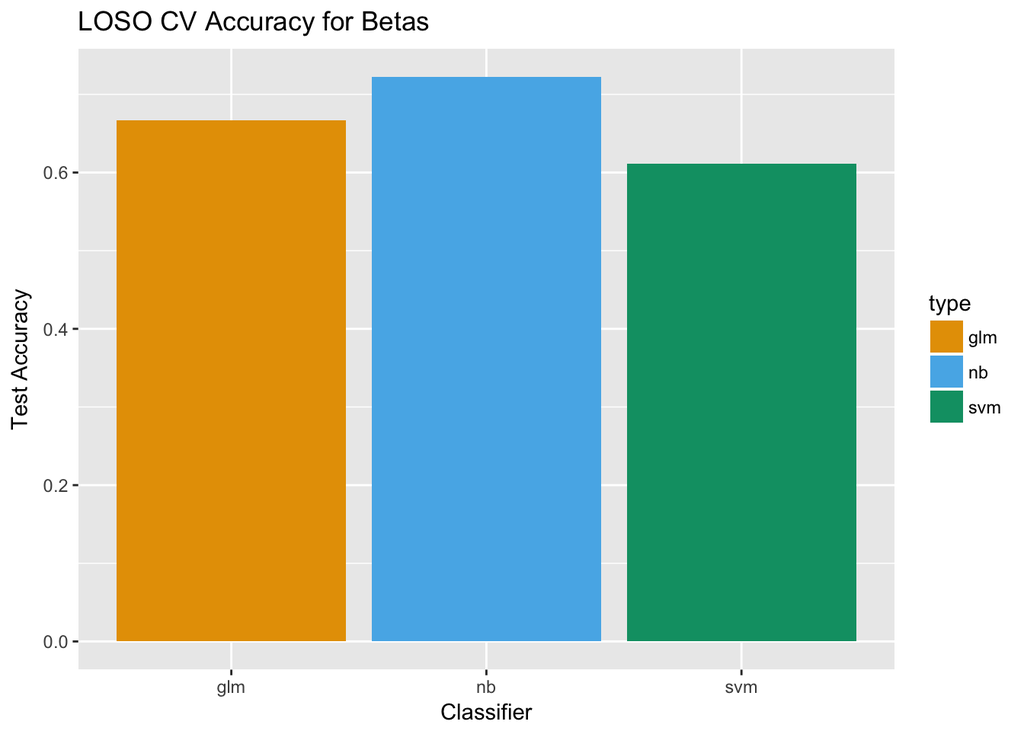

```r
results <- rbind(res.glm, res.svm, res.nb)
results$type <- c('glm', 'svm', 'nb')

library(ggplot2)
cbPalette <- c("#E69F00", "#56B4E9", "#009E73", "#F0E442", "#0072B2", "#D55E00", "#CC79A7")

ggplot(results, aes(x=type, y = test.accuracy), color=type, fill=type) +
  geom_bar(stat='identity', aes(fill=type)) +
  scale_fill_manual(values=cbPalette) +
  ggtitle("LOSO CV Accuracy for Betas") +
  xlab("Classifier") +
  ylab("Test Accuracy")
```

```r
ggsave('loso_cv_accuracy.png')
```